# Features affecting Trip Duration for Ford GoBikes

## by **Mark Wamiru**

## Investigation Overview

In my investigation, I wanted to figure out the features that had a role in the length or duration of bike trips. My main focus was on **duration**, **gender**, **user_type** and **bike_sharing**.

## Dataset Overview

The data consisted of duration in seconds and attributes of approximately 183,000 bike trips. The attributes included the gender, user type, bike sharing as well as additional features such as start_staion_id, end_staion_id and bike_id just to name a few. Approximately 8500 records were removed from the analysis due to inconsistencies or missing information. I added a new feature, **age**, which was used in the analysis.

## Distribution of trip duration

Most trips were about 500 seconds

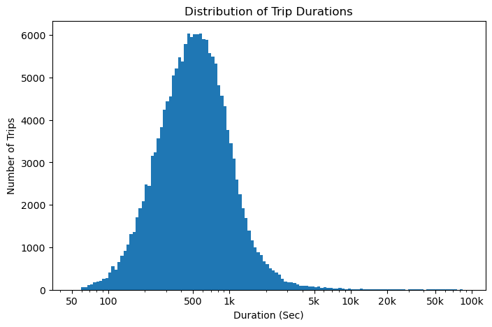

## Distribution of Gender

In general, males went for trips more than any of the other genders, making up 74.59% of the distribution.

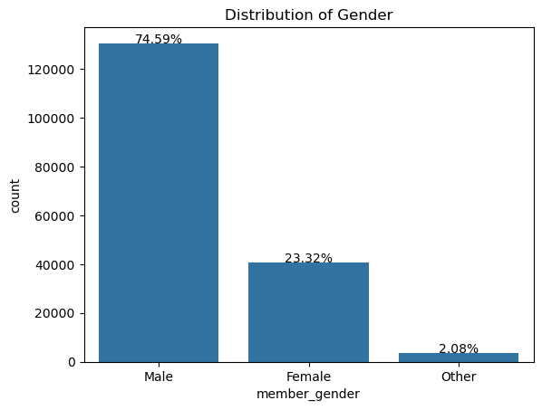

## Distribution of duration in relation to gender

Males tended to have the shortest trips among the 3 genders, with **others** having the longest trips.

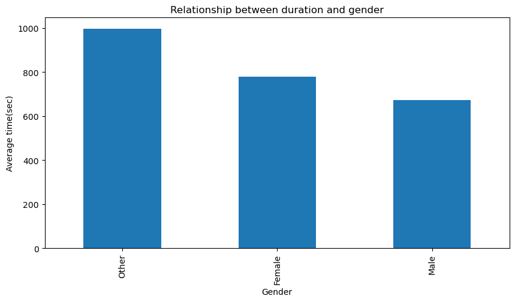

## Trip duration across user_type and bike_share_for_all_trip

Bike sharing isn't available for user type customers or customers never requested to share bikes. However, customer user type tend to have longer trips than subscriber in the category forthose who don't share bikes.

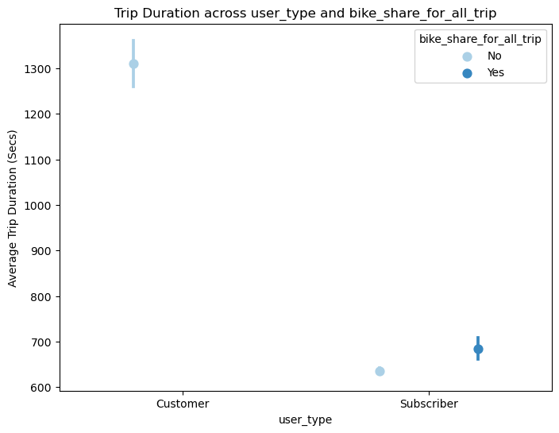

## Trip duration across gender and bike_share_for_all_trip

The `other` gender group travels for the longest duration for bike sharing and non bike sharing categories, followed by `female` then `male`.

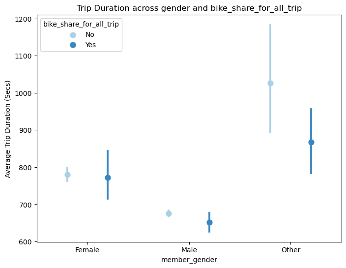